# Rossmann Store Sale

## 这里kaggle的一个竞赛项目，预测未来日期的销售额。除训练集外，还有一个补充的数据。

先粗略的看一下数据集。

```
##    Store DayOfWeek       Date Sales Customers Open Promo StateHoliday
## 1      1         5 2015-07-31  5263       555    1     1            0
## 2      2         5 2015-07-31  6064       625    1     1            0
## 3      3         5 2015-07-31  8314       821    1     1            0
## 4      4         5 2015-07-31 13995      1498    1     1            0
## 5      5         5 2015-07-31  4822       559    1     1            0
## 6      6         5 2015-07-31  5651       589    1     1            0
## 7      7         5 2015-07-31 15344      1414    1     1            0
## 8      8         5 2015-07-31  8492       833    1     1            0
## 9      9         5 2015-07-31  8565       687    1     1            0
## 10    10         5 2015-07-31  7185       681    1     1            0
##    SchoolHoliday
## 1              1
## 2              1
## 3              1
## 4              1
## 5              1
## 6              1
## 7              1
## 8              1
## 9              1
## 10             1
```

```
##         Store DayOfWeek       Date Sales Customers Open Promo StateHoliday
## 1017200  1106         2 2013-01-01     0         0    0     0            a
## 1017201  1107         2 2013-01-01     0         0    0     0            a
## 1017202  1108         2 2013-01-01     0         0    0     0            a
## 1017203  1109         2 2013-01-01     0         0    0     0            a
## 1017204  1110         2 2013-01-01     0         0    0     0            a
## 1017205  1111         2 2013-01-01     0         0    0     0            a
## 1017206  1112         2 2013-01-01     0         0    0     0            a
## 1017207  1113         2 2013-01-01     0         0    0     0            a
## 1017208  1114         2 2013-01-01     0         0    0     0            a
## 1017209  1115         2 2013-01-01     0         0    0     0            a
##         SchoolHoliday
## 1017200             1
## 1017201             1
## 1017202             1
## 1017203             1
## 1017204             1
## 1017205             1
## 1017206             1
## 1017207             1
## 1017208             1
## 1017209             1
```

大概可以看出，这个数据集是按日期时间倒序排列的。Sales和Customers这两个变量是我们要预测的目标。

```
##    Store StoreType Assortment CompetitionDistance
## 1      1         c          a                1270
## 2      2         a          a                 570
## 3      3         a          a               14130
## 4      4         c          c                 620
## 5      5         a          a               29910
## 6      6         a          a                 310
## 7      7         a          c               24000
## 8      8         a          a                7520
## 9      9         a          c                2030
## 10    10         a          a                3160
##    CompetitionOpenSinceMonth CompetitionOpenSinceYear Promo2
## 1                          9                     2008      0
## 2                         11                     2007      1
## 3                         12                     2006      1
```

[output cut: 18 more lines]

这个Dataframe是各商店的补充信息，包括了竞争对手的情报和promotion的信息。

## 分析训练集

先通过summary对训练集有一个大概的了解。

```
## [1] "Store"         "DayOfWeek"     "Date"          "Sales"
## [5] "Customers"     "Open"          "Promo"         "StateHoliday"
## [9] "SchoolHoliday"
```

```
##      Store          DayOfWeek             Date             Sales
##  Min.   :   1.0   Min.   :1.000   2013-01-02:   1115   Min.   :    0
##  1st Qu.: 280.0   1st Qu.:2.000   2013-01-03:   1115   1st Qu.: 3727
##  Median : 558.0   Median :4.000   2013-01-04:   1115   Median : 5744
##  Mean   : 558.4   Mean   :3.998   2013-01-05:   1115   Mean   : 5774
##  3rd Qu.: 838.0   3rd Qu.:6.000   2013-01-06:   1115   3rd Qu.: 7856
##  Max.   :1115.0   Max.   :7.000   2013-01-07:   1115   Max.   :41551
##                                   (Other)   :1010519
##    Customers           Open            Promo        StateHoliday
##  Min.   :   0.0   Min.   :0.0000   Min.   :0.0000   0:986159
##  1st Qu.: 405.0   1st Qu.:1.0000   1st Qu.:0.0000   a: 20260
##  Median : 609.0   Median :1.0000   Median :0.0000   b:  6690
##  Mean   : 633.1   Mean   :0.8301   Mean   :0.3815   c:  4100
##  3rd Qu.: 837.0   3rd Qu.:1.0000   3rd Qu.:1.0000
##  Max.   :7388.0   Max.   :1.0000   Max.   :1.0000
##
##  SchoolHoliday
##  Min.   :0.0000
##  1st Qu.:0.0000
##  Median :0.0000
##  Mean   :0.1786
##  3rd Qu.:0.0000
##  Max.   :1.0000
##
```

这里有9个变量除去预测变量，有7个变量是模型训练可能用到的特征。Store是分店的ID，我们要预测的就是这1115个分店的未来销售情况。Date这个变量每个都有1115条记录，对应1115个分店。

```
## 'data.frame':    1017209 obs. of  9 variables:
##  $ Store        : int  1 2 3 4 5 6 7 8 9 10 ...
##  $ DayOfWeek    : int  5 5 5 5 5 5 5 5 5 5 ...
##  $ Date         : Factor w/ 942 levels "2013-01-01","2013-01-02",..: 942 942 942 942 942 942 942 942 942 942 ...
##  $ Sales        : int  5263 6064 8314 13995 4822 5651 15344 8492 8565 7185 ...
##  $ Customers    : int  555 625 821 1498 559 589 1414 833 687 681 ...
##  $ Open         : int  1 1 1 1 1 1 1 1 1 1 ...
##  $ Promo        : int  1 1 1 1 1 1 1 1 1 1 ...
##  $ StateHoliday : Factor w/ 4 levels "0","a","b","c": 1 1 1 1 1 1 1 1 1 1 ...
##  $ SchoolHoliday: int  1 1 1 1 1 1 1 1 1 1 ...
```

### 根据kaggle项目对变量的定义，对以下几个变量进行类型转换。

```
## 'data.frame':    1017209 obs. of  9 variables:
##  $ Store        : int  1 2 3 4 5 6 7 8 9 10 ...
##  $ DayOfWeek    : int  5 5 5 5 5 5 5 5 5 5 ...
##  $ Date         : Date, format: "2015-07-31" "2015-07-31" ...
##  $ Sales        : int  5263 6064 8314 13995 4822 5651 15344 8492 8565 7185 ...
##  $ Customers    : int  555 625 821 1498 559 589 1414 833 687 681 ...
##  $ Open         : Factor w/ 2 levels "0","1": 2 2 2 2 2 2 2 2 2 2 ...
##  $ Promo        : Factor w/ 2 levels "0","1": 2 2 2 2 2 2 2 2 2 2 ...
##  $ StateHoliday : Factor w/ 4 levels "0","a","b","c": 1 1 1 1 1 1 1 1 1 1 ...
##  $ SchoolHoliday: Factor w/ 2 levels "0","1": 2 2 2 2 2 2 2 2 2 2 ...
```

## 单变量分析

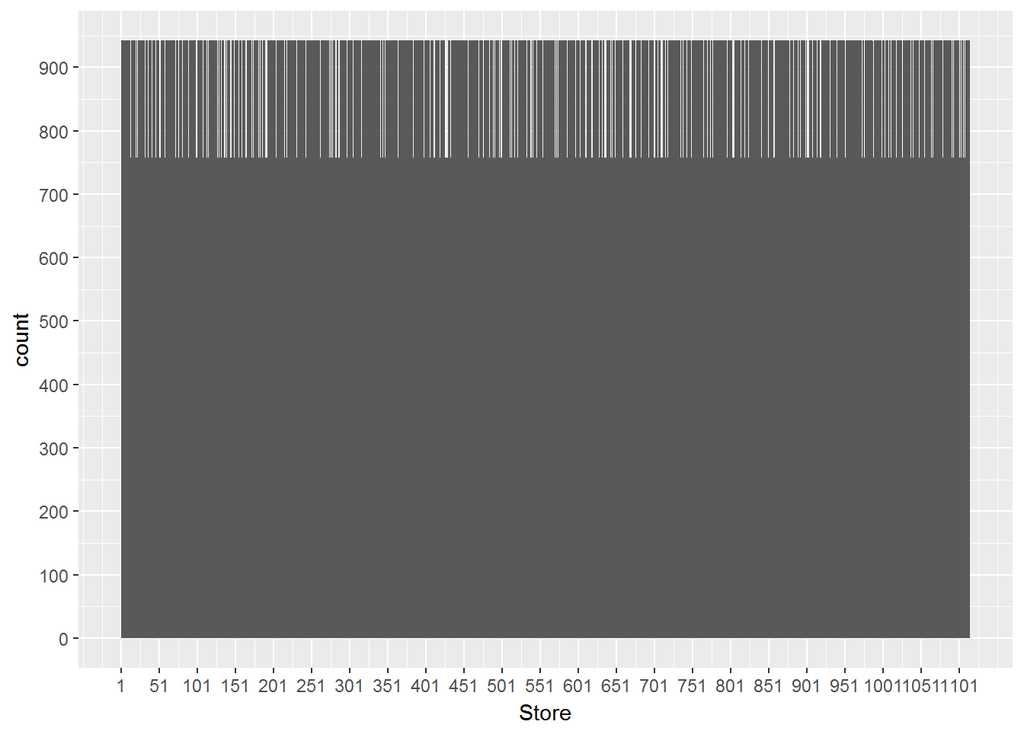

这里可以看出 有些门店的记录要少于其它门店，并且少的数量也似乎一样。

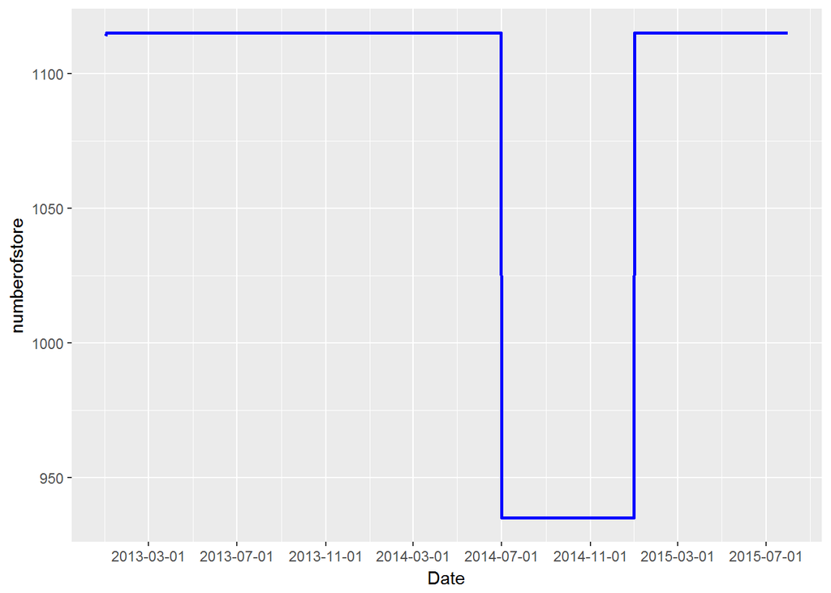

我们发现总共有180个分店缺少一部分从2014/7到2015/1的销售记录。考虑到这个任务的目标和训练集都是日期序列的，这部分缺失值可能会让模型无法捕捉到这些门店在这些月间一些周期性或季节性的特征。

```
## # A tibble: 180 x 2
##    Store   num
##    <int> <int>
##  1    13   758
##  2    20   758
##  3    22   758
##  4    32   758
##  5    36   758
##  6    41   758
##  7    46   758
##  8    51   758
##  9    52   758
## 10    58   758
## # ... with 170 more rows
```

### 对数据集操作：增加一个临时变量指出门店是否有缺失数据以便分析。

```
##
##      0      1
## 880769 136440
```

接下来看DayOfWeek

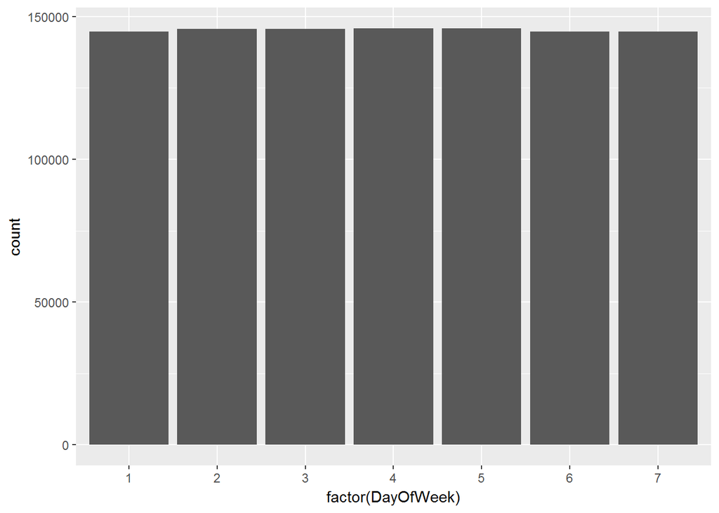

通过柱状图我们看出这个变量呈均匀分布。

现在看看StateHoliday变量，这关系到分店是否开门营业。

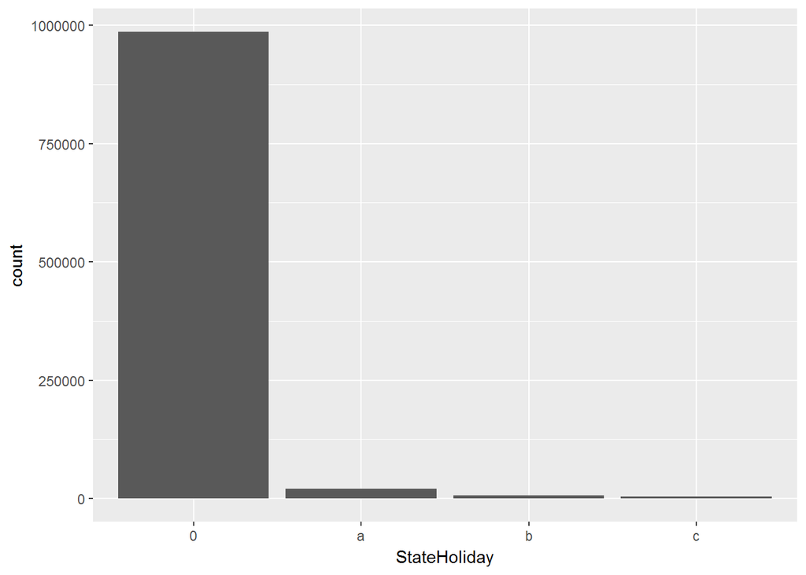

通常来讲，大部分门店会在节假日关门，这里0 表示不是节目。可以看出，stateholiday占非常小的比例。

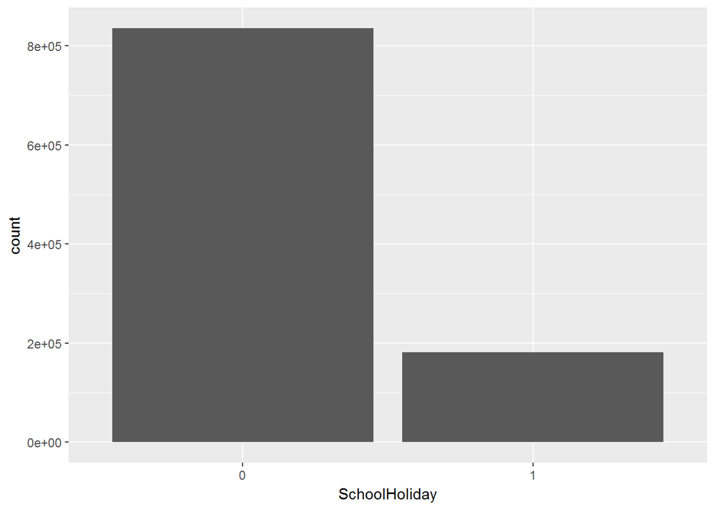

这个变量表明一个分店是否受到学校假期的影响。对于0，1并没有明确的说明，那么这里猜测1是有影响0是没有。通常学校在周末也会放假。直觉上，应该这两个变量都跟Open有关系。这里可以看出受影响的比例并不高。

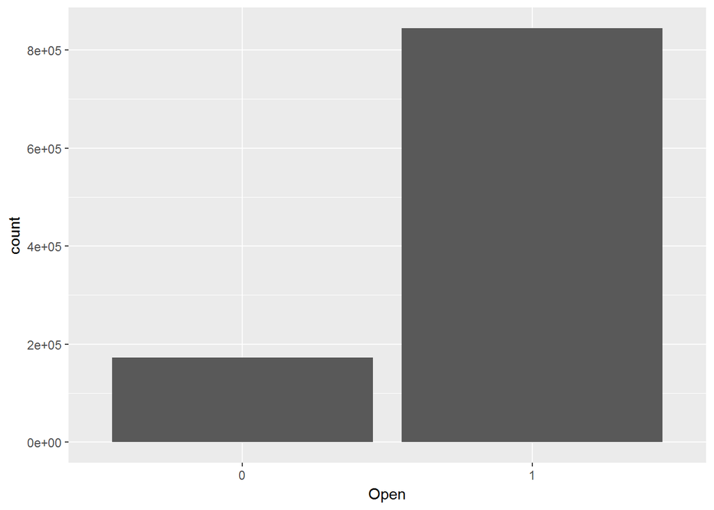

Open变量0=close,1=open.这里可以看出，大部分的情况分店是开门的这也符合对前面两个变量的分析。 有一点值得注意的是，在项目说明里我们了解到有些门店因为翻修的原因而暂时关闭了。我们也许可以考虑增加一个变量来表示是否那天门店关门是因为装修。这个可以粗略的将关门日期中不是因为两种假期的情况，需要进一步分析才能确定。

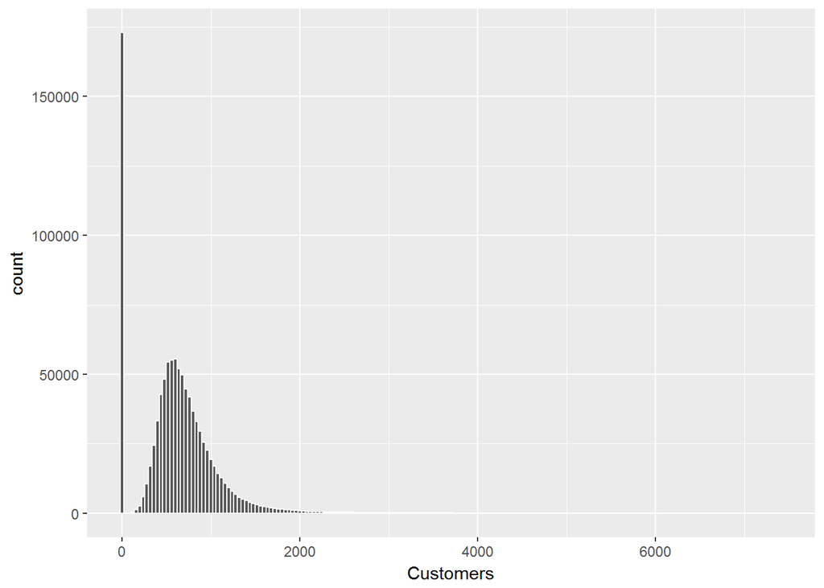

我们看到有很大一部分进店客户数量是0的情况，考虑可能跟Open变量有关。而右边大于0的销售部分近似正态分布，右端有少量异常值。

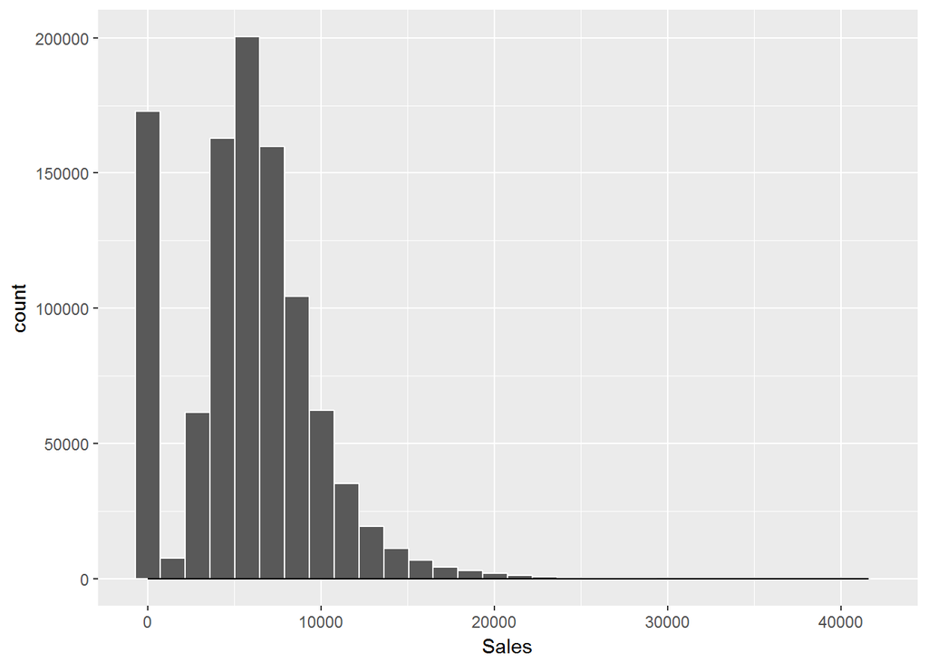

这两个预测变量基本上分布有些相似，销售为0的占了很大的比例。在右端有一些异常分布。

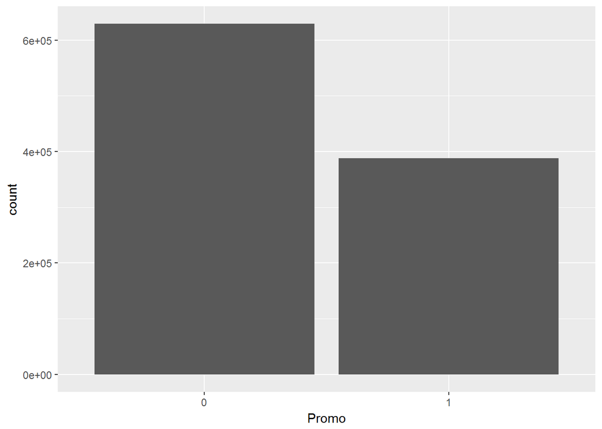

Promo变量的柱状图显示没有促销活动的占更多的比例。

# 双变量分析

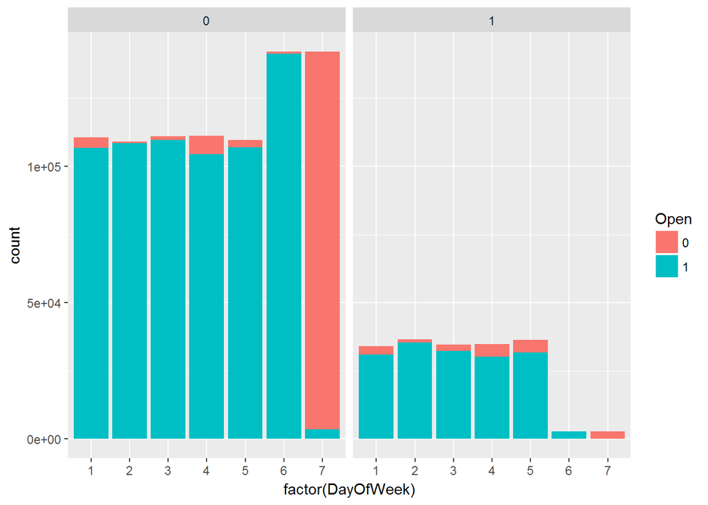

首先可以看出第7天几乎所有门店都关门了，只有少数跟学校假期没有关系的门店开门。这符合上面对0，1代表分类的猜测。

进一步观察可能跟Open有关系的变量

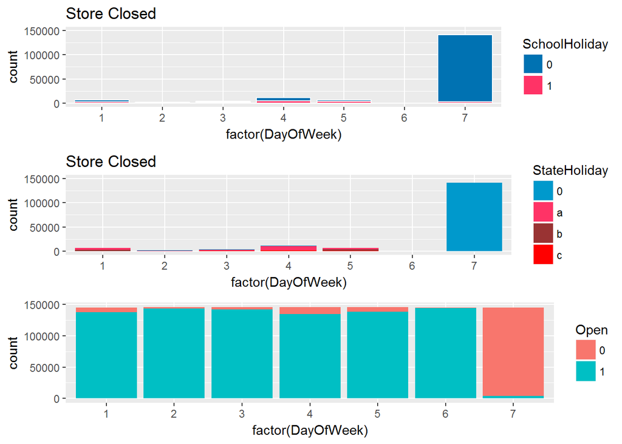

通过对比，可以看出1到5这几天中关门的情况跟StateHoliday基本上一致。

接着看下在1到6这几天里不是任何节假日的情况下有哪些门店关门了，时间是多久。

```
## [1] 143
```

通过unique函数，可以看出有143家分店在这三年间可能因店面翻新而关店一段时间。

```
##      Store          DayOfWeek          Date                Sales
##  Min.   :   5.0   Min.   :1.000   Min.   :2013-01-05   Min.   :0
##  1st Qu.: 339.0   1st Qu.:2.000   1st Qu.:2013-03-08   1st Qu.:0
##  Median : 659.0   Median :3.000   Median :2013-07-03   Median :0
##  Mean   : 591.1   Mean   :3.416   Mean   :2013-11-04   Mean   :0
##  3rd Qu.: 909.0   3rd Qu.:5.000   3rd Qu.:2014-06-15   3rd Qu.:0
##  Max.   :1110.0   Max.   :6.000   Max.   :2015-07-25   Max.   :0
##    Customers Open     Promo   StateHoliday SchoolHoliday HaveMissDate
##  Min.   :0   0:1422   0:789   0:1422       0:1422        0:1285
##  1st Qu.:0   1:   0   1:633   a:   0       1:   0        1: 137
##  Median :0                    b:   0
##  Mean   :0                    c:   0
##  3rd Qu.:0
##  Max.   :0
```

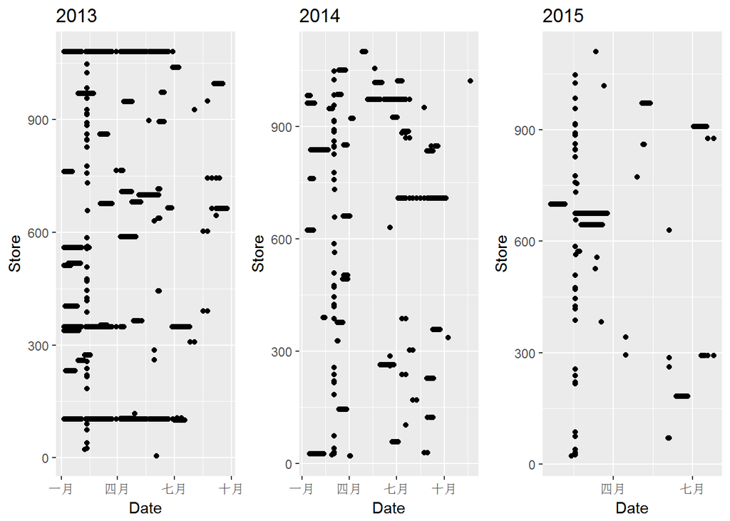

观察可知有少量门店每隔一小段时间或者一段时间有关门的情况，这部分应该符合关门翻修关店的情况。但是其中有三个时间点大部分门店有短时间的关店，这可能不太符合翻修情况。需要对这些月份的数据进一步观察。

```
##        Store DayOfWeek       Date Sales Customers Open Promo StateHoliday
## 184000    25         1 2015-02-16     0         0    0     1            0
## 184005    30         1 2015-02-16     0         0    0     1            0
## 184015    40         1 2015-02-16     0         0    0     1            0
## 184049    74         1 2015-02-16     0         0    0     1            0
## 184061    86         1 2015-02-16     0         0    0     1            0
## 184191   216         1 2015-02-16     0         0    0     1            0
## 184195   220         1 2015-02-16     0         0    0     1            0
## 184213   238         1 2015-02-16     0         0    0     1            0
## 184231   256         1 2015-02-16     0         0    0     1            0
## 184362   387         1 2015-02-16     0         0    0     1            0
## 184393   418         1 2015-02-16     0         0    0     1            0
## 184400   425         1 2015-02-16     0         0    0     1            0
## 184420   445         1 2015-02-16     0         0    0     1            0
## 184445   470         1 2015-02-16     0         0    0     1            0
```

[output cut: 51 more lines]

这里有32个门店2月16号临时关门而无法从已知变量中找到原因。 看下其它年份2/16号的情况

```
##    0    a    b    c
## 3345    0    0    0
```

```
##    0    1
## 3090  255
```

可以看出其它年份2/16并不是一个特殊的日期。 考虑到测试集中open是确定的，这里不再做进一步的探索。 接下来看另一个变量，这里关店的情况应该排除

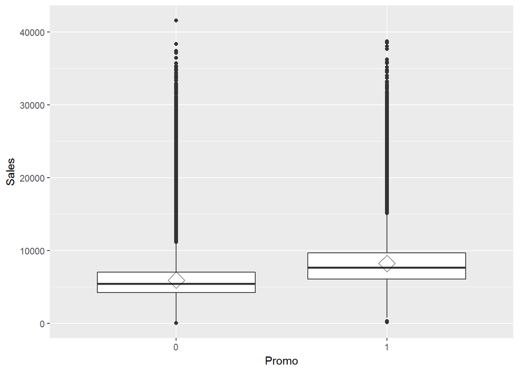

从箱形图可以看出两者分布，有promo的销售额的整体略高于没有promo的情况。同时可以看到两个箱子顶端分布了不少异常值，这可能跟数据集规模有关。等进一步分析。

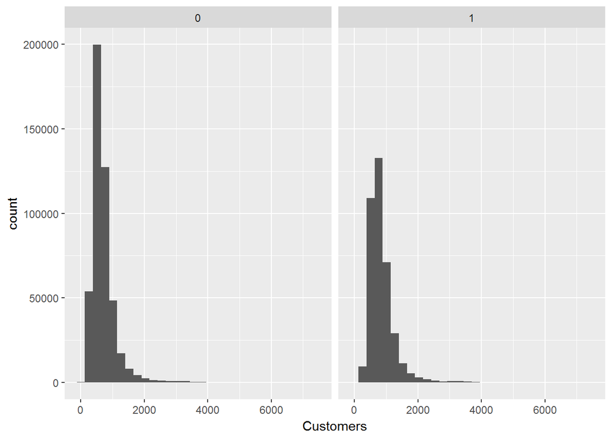

嗯，看起来促销并没有增加更多的进店客户，结合销售额与Promo的关系，推测promo提升了人均消费。

接下来我们来看每个门店的销售有没有不同。

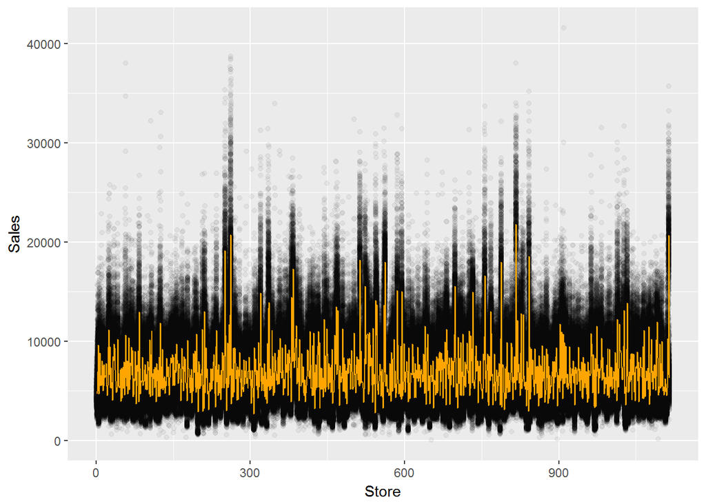

明显看出，有些分店的平均销售额要远高于其它分店。

接下来看下假期跟销售额的关系 (代码参考kaggle kernal)

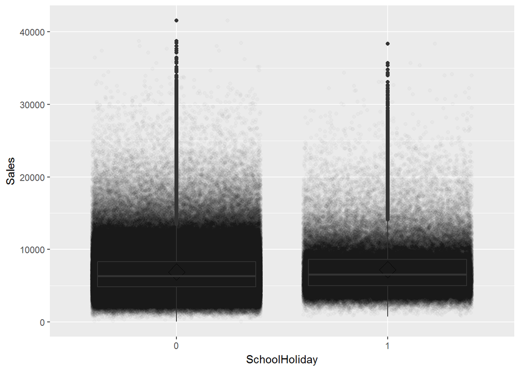

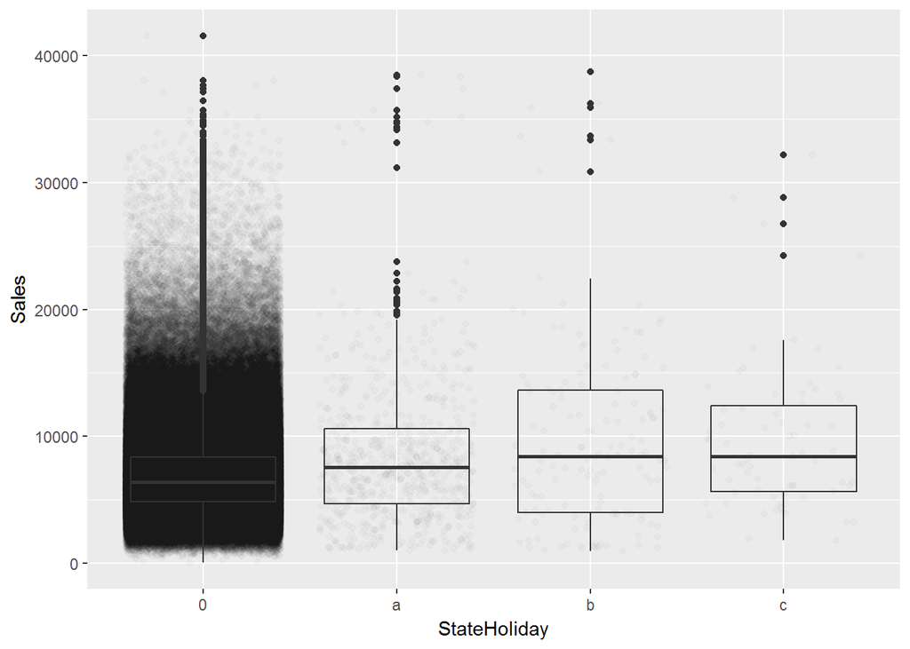

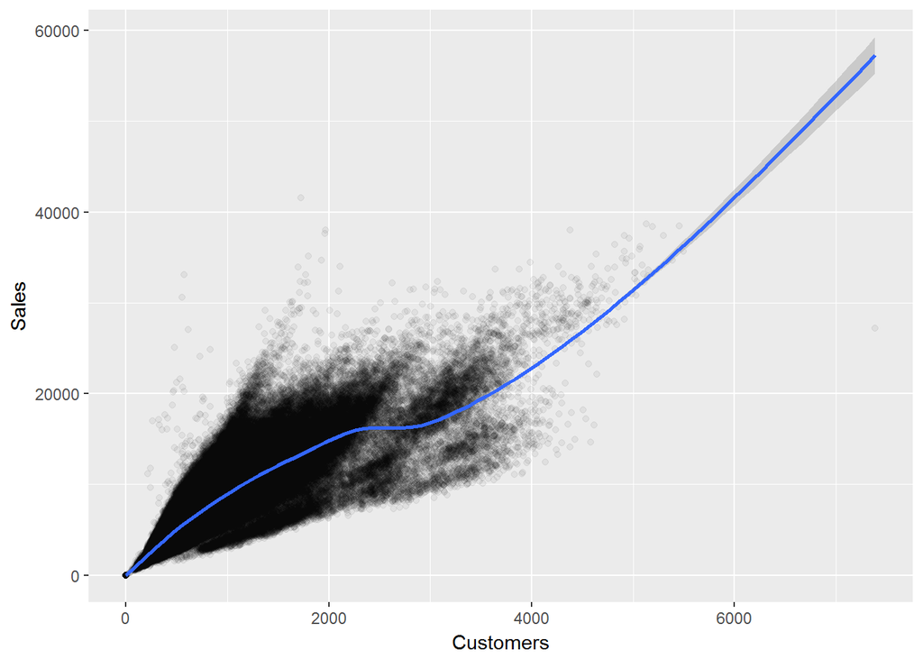

可以看出这两个变量线性相关，并少量异常值分布。

接下来，看Dayofweek跟Sales的关系。这里去掉了Sales为0的情况。因为前面分析单变量的时候，我们知道周日只有非常少的店铺是开门的情况，如果不排除掉销售为0的情况，可能不容易看出这两个变量的关系。

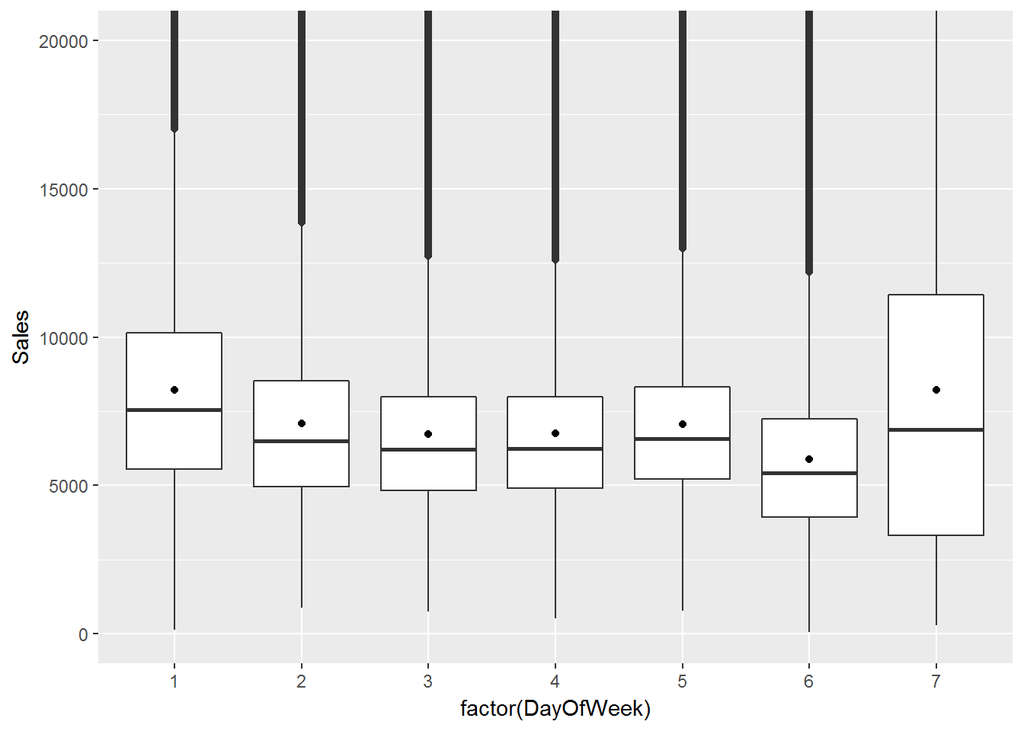

这里我们看到，第7天的IQR相对较大而且均值也比较高。从箱型图可以看出这两个变量存在一些相关性。我们可以通过cor.test函数进一步查看。

```
##
##  Pearson's product-moment correlation
##
## data:  DayOfWeek and Sales
## t = -525.57, df = 1017200, p-value < 2.2e-16
## alternative hypothesis: true correlation is not equal to 0
## 95 percent confidence interval:
##  -0.4636520 -0.4605953
## sample estimates:
##       cor
## -0.462125
```

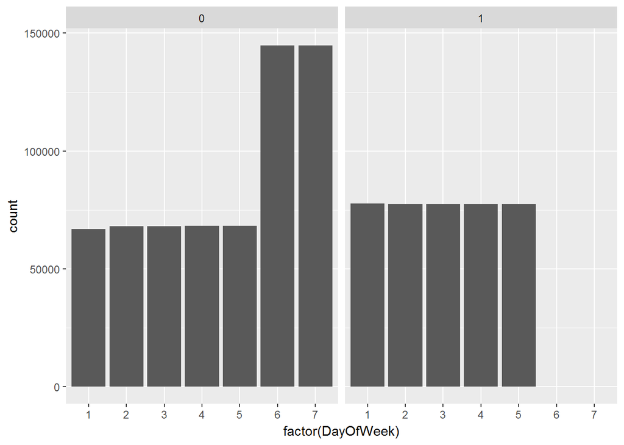

这里可以看出第6天和第7天没有门店做Promo的促销活动。其它时间，两种分布同单变量分析的结果。

## 第二个dataframe

```
##      Store        StoreType Assortment CompetitionDistance
##  Min.   :   1.0   a:602     a:593      Min.   :   20.0
##  1st Qu.: 279.5   b: 17     b:  9      1st Qu.:  717.5
##  Median : 558.0   c:148     c:513      Median : 2325.0
##  Mean   : 558.0   d:348                Mean   : 5404.9
##  3rd Qu.: 836.5                        3rd Qu.: 6882.5
##  Max.   :1115.0                        Max.   :75860.0
##                                        NA's   :3
##  CompetitionOpenSinceMonth CompetitionOpenSinceYear     Promo2
##  Min.   : 1.000            Min.   :1900             Min.   :0.0000
##  1st Qu.: 4.000            1st Qu.:2006             1st Qu.:0.0000
##  Median : 8.000            Median :2010             Median :1.0000
##  Mean   : 7.225            Mean   :2009             Mean   :0.5121
##  3rd Qu.:10.000            3rd Qu.:2013             3rd Qu.:1.0000
##  Max.   :12.000            Max.   :2015             Max.   :1.0000
##  NA's   :354               NA's   :354
##  Promo2SinceWeek Promo2SinceYear          PromoInterval
##  Min.   : 1.0    Min.   :2009                    :544
##  1st Qu.:13.0    1st Qu.:2011    Feb,May,Aug,Nov :130
##  Median :22.0    Median :2012    Jan,Apr,Jul,Oct :335
##  Mean   :23.6    Mean   :2012    Mar,Jun,Sept,Dec:106
##  3rd Qu.:37.0    3rd Qu.:2013
##  Max.   :50.0    Max.   :2015
##  NA's   :544     NA's   :544
```

```
## 'data.frame':    1115 obs. of  10 variables:
##  $ Store                    : int  1 2 3 4 5 6 7 8 9 10 ...
##  $ StoreType                : Factor w/ 4 levels "a","b","c","d": 3 1 1 3 1 1 1 1 1 1 ...
##  $ Assortment               : Factor w/ 3 levels "a","b","c": 1 1 1 3 1 1 3 1 3 1 ...
##  $ CompetitionDistance      : int  1270 570 14130 620 29910 310 24000 7520 2030 3160 ...
##  $ CompetitionOpenSinceMonth: int  9 11 12 9 4 12 4 10 8 9 ...
##  $ CompetitionOpenSinceYear : int  2008 2007 2006 2009 2015 2013 2013 2014 2000 2009 ...
##  $ Promo2                   : int  0 1 1 0 0 0 0 0 0 0 ...
##  $ Promo2SinceWeek          : int  NA 13 14 NA NA NA NA NA NA NA ...
##  $ Promo2SinceYear          : int  NA 2010 2011 NA NA NA NA NA NA NA ...
##  $ PromoInterval            : Factor w/ 4 levels "","Feb,May,Aug,Nov",..: 1 3 3 1 1 1 1 1 1 1 ...
```

这里有10个变量1115个观察对象分别是1115的分店。考虑将变量分成三部分来分析 1:Type.2:competition.3:promo2

## 单变量分析

首先，先看下storetype&asortment.前者是4种不同类型，后者表示分类的级别a = basic, b = extra, c = extended

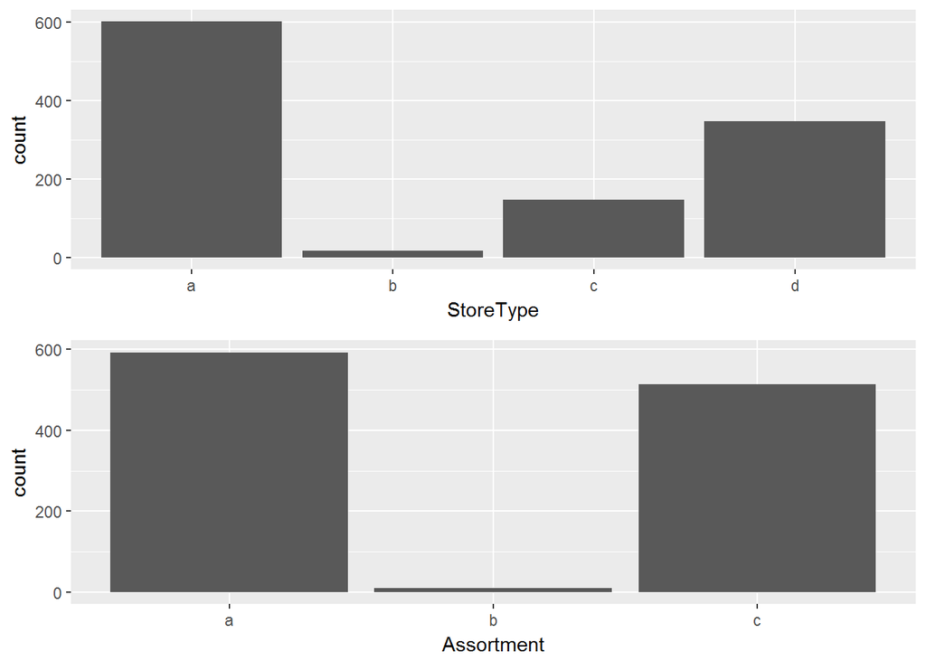

从柱状图来看，分类变量跟分类级别没有太大的关联性。在assortment 类型a和c中storetype都有分布，仅b非常特殊，同时b的比例非常非常小。

## Competition

这几个变量里有不少缺失值，我们来逐个看下。

```
##     Store StoreType Assortment CompetitionDistance
## 291   291         d          a                  NA
## 622   622         a          c                  NA
##     CompetitionOpenSinceMonth CompetitionOpenSinceYear Promo2
## 291                        NA                       NA      0
## 622                        NA                       NA      0
##     Promo2SinceWeek Promo2SinceYear PromoInterval
## 291              NA              NA
## 622              NA              NA
```

```
##    Store StoreType Assortment CompetitionDistance
## 12    12         a          c                1070
## 13    13         d          a                 310
##    CompetitionOpenSinceMonth CompetitionOpenSinceYear Promo2
## 12                        NA                       NA      1
## 13                        NA                       NA      1
##    Promo2SinceWeek Promo2SinceYear   PromoInterval
## 12              13            2010 Jan,Apr,Jul,Oct
## 13              45            2009 Feb,May,Aug,Nov
```

Competion的几个变量描述了离分店最近的竞争者的开店时间和距离。这里有351个分店有距离信息但是缺少开店时间。这里推测可能是信息无法获取或者因为开店日期是训练集之后的日期而被移除（可能性比较小）。考虑到这部分缺失值占30%分店比例，在合并前需要做进一步处理，否则会给训练集制造出一大堆的na值。 这里解决方案有两个：1，根据该变量与预测值的相关性，是否是必要的。2，查看这个变量的分布情况，是否可以用均值来填充。

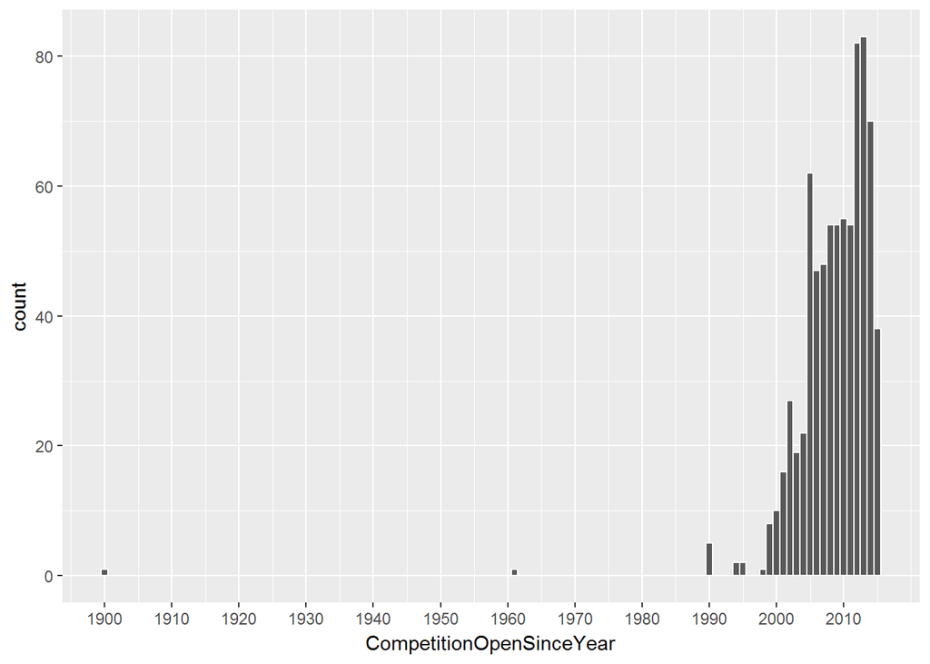

从直方图来看，分布偏态，1990年前的两个值应该是异常值。考虑去掉或者换成均值。

```
##    Min. 1st Qu.  Median    Mean 3rd Qu.    Max.    NA's
##    1900    2006    2010    2009    2013    2015     354
```

```
##    Min. 1st Qu.  Median    Mean 3rd Qu.    Max.    NA's
##   1.000   4.000   8.000   7.225  10.000  12.000     354
```

从summary来看，均值和中位数非常接近。

思路： 1考虑合并CompetitionOpenSinceYear和CompetitionOpenSinceMonth这两个变量做为训练用特征 2.增加一个值为1，0的变量CompetionOpen，比如如果开店时间是2010/5，那么所有这个日期之后的该分店的competionopen值为1.反之为0.即表示那一天这个店是否有competion。这样操作的考虑模型需要预测出每一日期每个分店的销售额，这样可以区分开不同日期的差别。但是同时需要考虑到测试集上的日期是在2015之后的，也就是说这种处理方式只会给测试集增加一个值全部为1的变量。这样看起来似乎没什么意义。 3.是否可以转化成一种代表竞争对手开店时间累积的变量？（思考）

变量StoreType中有一半的分店是a类型的。在Assortment中a水平分类也几乎点了一半,进一步查看这两个变量是否有关联或功能重复。

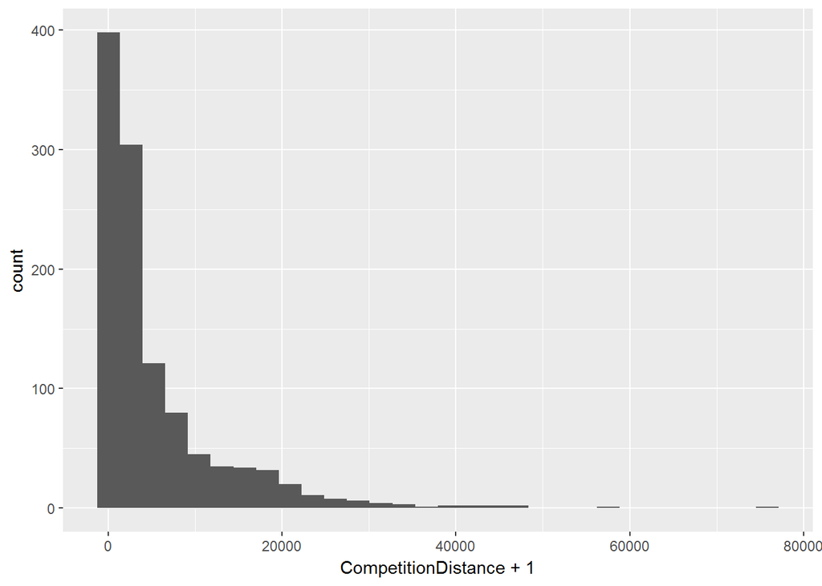

从直方图可以看出，这个变量呈偏态分布。大部分的样本集中在0到5000区间，有很长的尾巴，末端看起来有异常值。

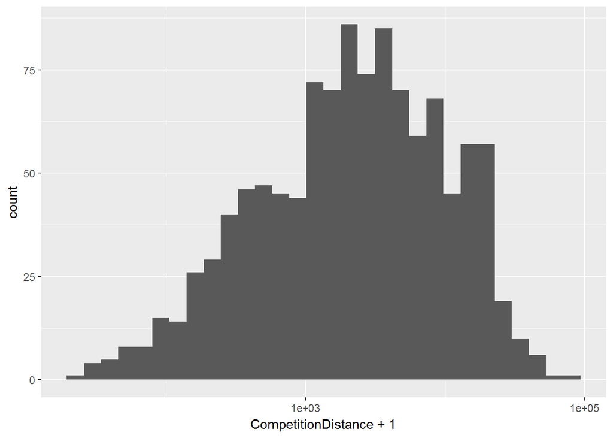

第二个直方图是经过对数转换之后，近似于正态分布。考虑对该变量做对数转换。 还有一种思路将变量分割成几个区间，每个区间是一个等级。这种处理方式可能对分析的时候有帮助，但是改变了整体特征空间，同时可能会增加一些不确定因素。比如区间该如何选择这个问题就引入了人为干扰。

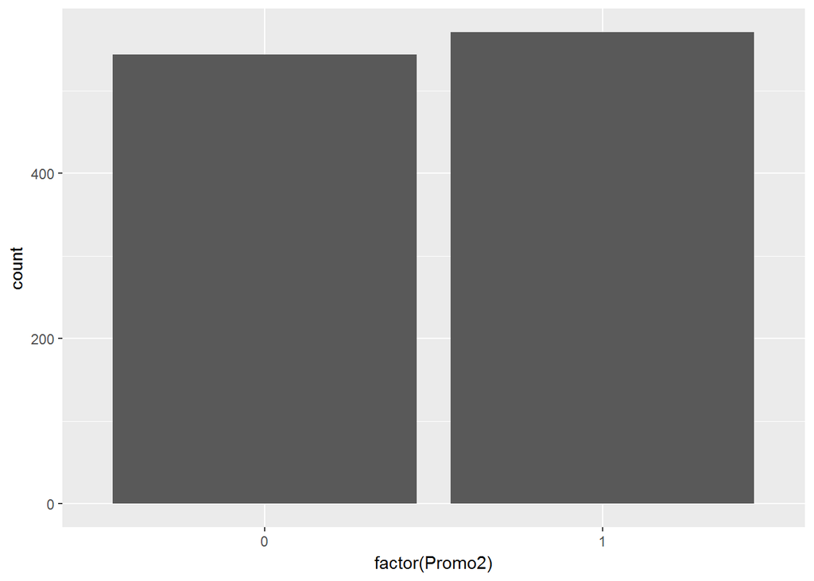

嗯，看起来参加这种促销的门店占了一半以上的比例。

接下来关于开始促销的时间中有两个变量分别是年和周，其中有544个na值。

```
##
##   0
## 544
```

544个门店并没有参加这类促销，因此相关变量全部为NA。

## 双变量分析

这里我们并不清楚storetype和分类依据，我们先将这两个变量同Promo2相关变量来做对比观察。

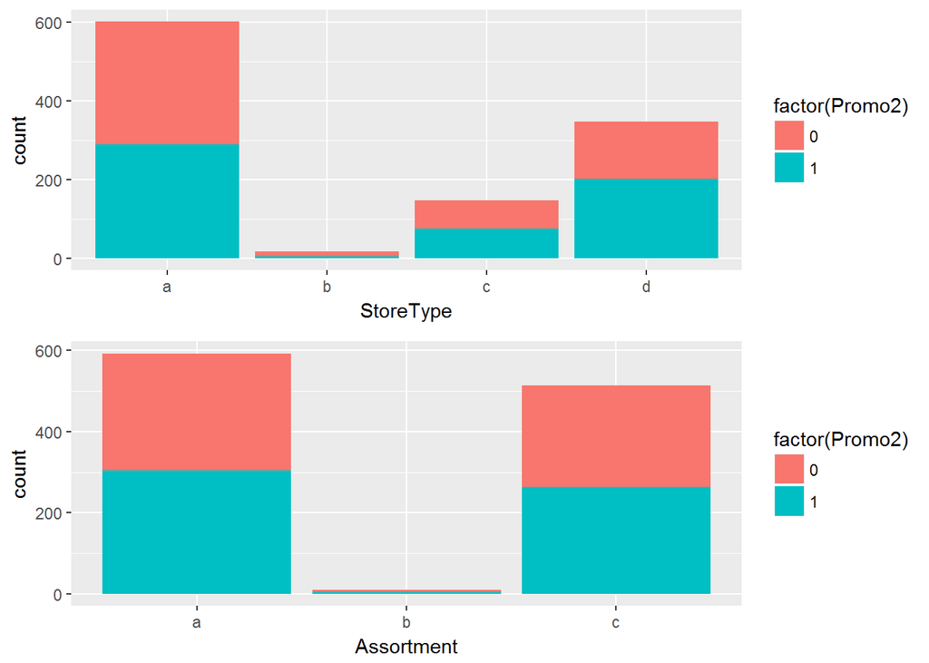

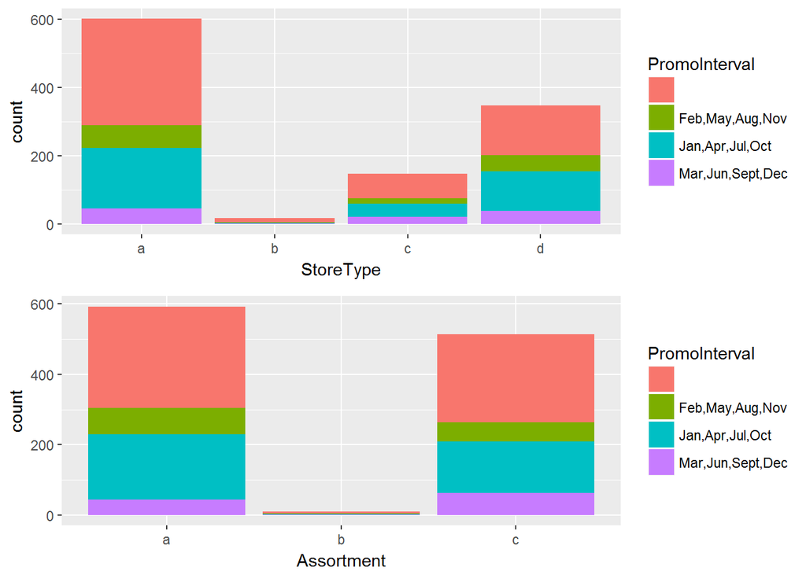

从图形上并没有发现相关性。

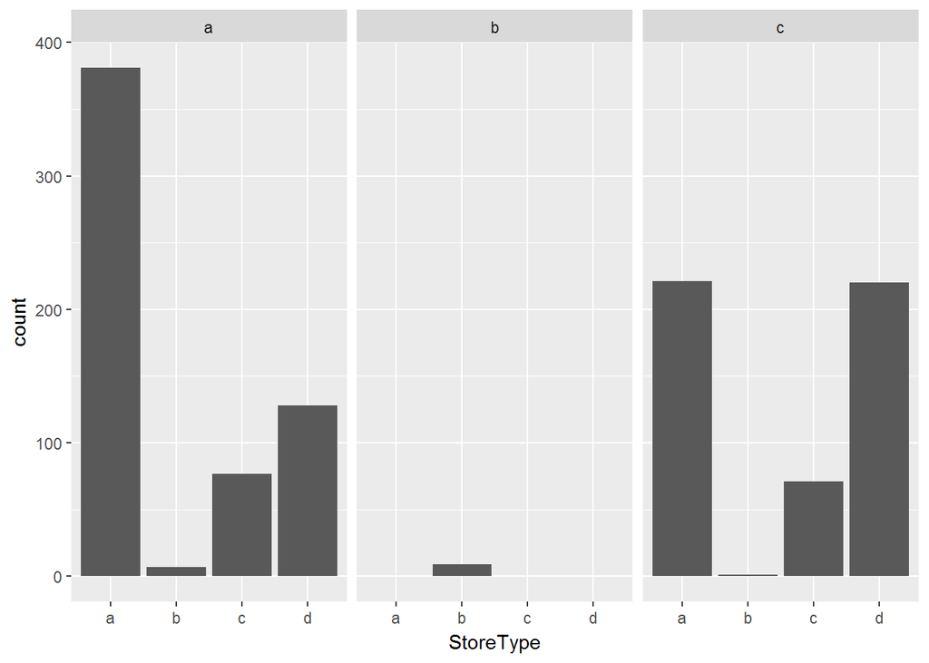

这里看出b非常特别，在a,c两种分类级别中都有a~d分布。而只有b分类级里只有b这一种type。

### 对train数据集操作：将storetype assorment合并到训练集

```
##      Store          DayOfWeek          Date                Sales
##  Min.   :   1.0   Min.   :1.000   Min.   :2013-01-01   Min.   :    0
##  1st Qu.: 280.0   1st Qu.:2.000   1st Qu.:2013-08-17   1st Qu.: 3727
##  Median : 558.0   Median :4.000   Median :2014-04-02   Median : 5744
##  Mean   : 558.4   Mean   :3.998   Mean   :2014-04-11   Mean   : 5774
##  3rd Qu.: 838.0   3rd Qu.:6.000   3rd Qu.:2014-12-12   3rd Qu.: 7856
##  Max.   :1115.0   Max.   :7.000   Max.   :2015-07-31   Max.   :41551
##    Customers      Open       Promo      StateHoliday SchoolHoliday
##  Min.   :   0.0   0:172817   0:629129   0:986159     0:835488
##  1st Qu.: 405.0   1:844392   1:388080   a: 20260     1:181721
##  Median : 609.0                         b:  6690
##  Mean   : 633.1                         c:  4100
##  3rd Qu.: 837.0
##  Max.   :7388.0
##  HaveMissDate StoreType  Assortment
##  0:880769     a:551627   a:537445
##  1:136440     b: 15830   b:  8294
##               c:136840   c:471470
##               d:312912
##
##
```

观察StoreType跟Sales是否有相关性。

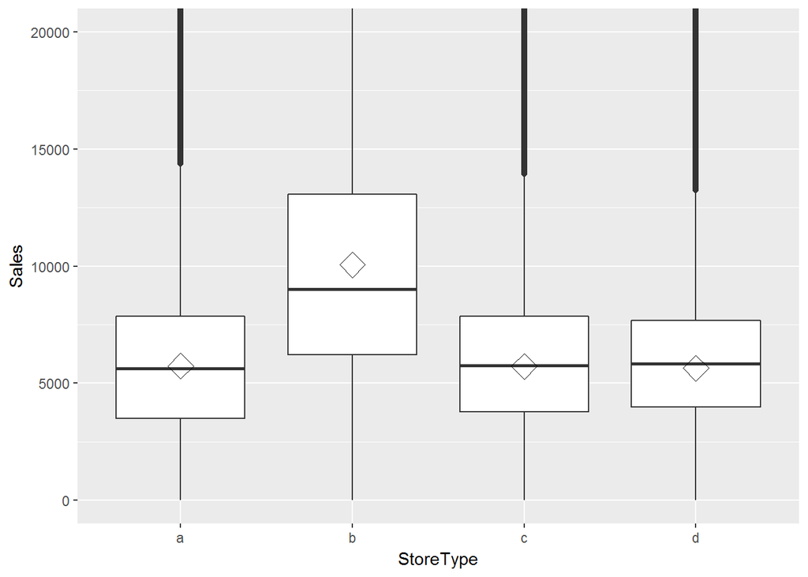

从箱型图可以看出,b类型的门店销售均值和中位数都高于其它类型。

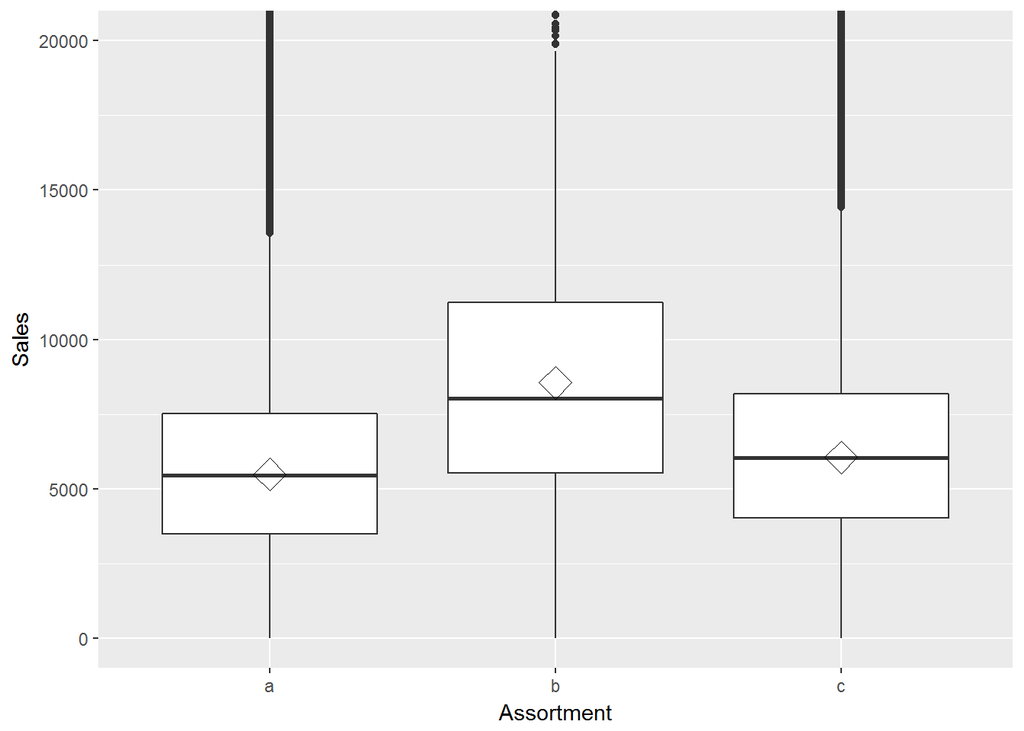

从箱型图来看a,c分布比较相似。b的销售均值及中位数明显高于其它类型，考虑到这也可能与b型样本量过小有关。

### 对数据集store_add操作：填充na值，合并competitionsince变量

```
##      Store        StoreType Assortment CompetitionDistance
##  Min.   :   1.0   a:602     a:593      Min.   :   20.0
##  1st Qu.: 279.5   b: 17     b:  9      1st Qu.:  717.5
##  Median : 558.0   c:148     c:513      Median : 2325.0
##  Mean   : 558.0   d:348                Mean   : 5404.9
##  3rd Qu.: 836.5                        3rd Qu.: 6882.5
##  Max.   :1115.0                        Max.   :75860.0
##                                        NA's   :3
##  CompetitionOpenSinceMonth CompetitionOpenSinceYear     Promo2
##  Min.   : 1.000            Min.   :1990             Min.   :0.0000
##  1st Qu.: 6.000            1st Qu.:2008             1st Qu.:0.0000
##  Median : 7.000            Median :2009             Median :1.0000
##  Mean   : 7.153            Mean   :2009             Mean   :0.5121
##  3rd Qu.: 9.000            3rd Qu.:2011             3rd Qu.:1.0000
##  Max.   :12.000            Max.   :2015             Max.   :1.0000
##
##  Promo2SinceWeek Promo2SinceYear          PromoInterval
##  Min.   : 1.0    Min.   :2009                    :544
##  1st Qu.:13.0    1st Qu.:2011    Feb,May,Aug,Nov :130
##  Median :22.0    Median :2012    Jan,Apr,Jul,Oct :335
##  Mean   :23.6    Mean   :2012    Mar,Jun,Sept,Dec:106
##  3rd Qu.:37.0    3rd Qu.:2013
##  Max.   :50.0    Max.   :2015
##  NA's   :544     NA's   :544
```

接下来我们把这部分变量合并到train里